# Single-Cell RNA-seq Analysis of Purkinje Cell Development

Mouse Cerebellum E16.5 - E18.5

Author

Glady Hazitha Samuel

Published

May 8, 2026

# 1 Introduction

## 1.1 Dataset Overview

This analysis examines Purkinje cell diversity during late embryonic cerebellar development using single-cell RNA-sequencing data from mouse cerebellum at two developmental stages:

- **E16.5**: 2 biological replicates
- **E18.5**: 1 biological replicate

**Data source**: GEO accession GSE256438  
**BioProject**: PRJNA1079673  
**Publication**: Khouri-Farah et al. (2025) *Nature Neuroscience* - “FOXP genes regulate Purkinje cell diversity and cerebellar morphogenesis”

**Biological context**: Purkinje cells (PCs) are GABAergic neurons born between E10.5-E13.5 in mice. By E16.5-E18.5, PCs are undergoing maturation characterized by dendritic arborization, synapse formation, and migration to form the Purkinje cell layer.

**Analysis goals**:

1. Characterize cellular composition of E16.5 and E18.5 cerebellum
2. Identify and classify Purkinje cell subtypes
3. Compare PC subtype composition between developmental stages
4. Identify genes and pathways differentially expressed during PC maturation
5. Analyze cell-cell communication networks during cerebellar development

# 2 Methods

## 2.1 Dataset Acquisition

### 2.1.1 Sample Information

| Sample ID | SRA Accession | Stage | Replicate | Description |
| --- | --- | --- | --- | --- |
| E16_rep1 | SRR28065511 | E16.5 | 1 | Embryonic day 16.5, replicate 1 |
| E16_rep2 | SRR28065512 | E16.5 | 2 | Embryonic day 16.5, replicate 2 |
| E18 | SRR28065510 | E18.5 | 1 | Embryonic day 18.5 |

### 2.1.2 Cell Ranger Alignment Results

| Metric | E18.5 (SRR28065510) | E16_rep1 (SRR28065511) | E16_rep2 (SRR28065512) |
| --- | --- | --- | --- |
| **Chemistry** | 3’ v2 | 3’ v3 | 3’ v2 |
| **Estimated cells** | 7,234 | 10,247 | 6,953 |
| **Mean reads/cell** | 52,315 | 40,531 | 41,166 |
| **Median genes/cell** | 2,953 | 4,357 | 2,917 |
| **Median UMI/cell** | 7,350 | 13,585 | 7,424 |
| **Reads mapped to genome** | 91.2% | 89.4% | 90.3% |
| **Reads mapped to transcriptome** | 80.3% | 74.8% | 79.4% |

**Quality assessment**: All samples showed high mapping rates (>89% to genome, >74% to transcriptome). E16_rep1 used 3’ v3 chemistry, resulting in higher gene/UMI capture compared to v2 chemistry.

# 3 Quality Control and Filtering

## 3.1 Rationale

Quality control filtering removes low-quality cells (empty droplets, debris, dying cells) while retaining biological variation to ensure downstream analysis reflects true biological signal.

## 3.2 Data Loading

Raw gene expression counts from Cell Ranger were loaded into R using the Seurat package. For each sample, we created a Seurat object containing the gene-by-cell count matrix. Stage labels were added to distinguish E16.5 from E18.5 samples. Mitochondrial gene percentage was calculated for each cell to assess cell viability (dying cells show elevated mitochondrial content). The three samples were then merged into a single Seurat object with unique cell identifiers to prevent barcode collisions between samples.

```r
library(Seurat)
library(dplyr)
library(ggplot2)

# Load Cell Ranger outputs
e16_rep1 <- Read10X("results/03_counts/01_cellranger/SRR28065511/outs/filtered_feature_bc_matrix/")
e16_rep2 <- Read10X("results/03_counts/01_cellranger/SRR28065512/outs/filtered_feature_bc_matrix/")
e18 <- Read10X("results/03_counts/01_cellranger/SRR28065510/outs/filtered_feature_bc_matrix/")

# Create Seurat objects
e16_rep1_obj <- CreateSeuratObject(counts = e16_rep1, project = "E16_rep1")
e16_rep2_obj <- CreateSeuratObject(counts = e16_rep2, project = "E16_rep2")
e18_obj <- CreateSeuratObject(counts = e18, project = "E18")

# Add metadata
e16_rep1_obj$stage <- "E16.5"
e16_rep2_obj$stage <- "E16.5"
e18_obj$stage <- "E18.5"

# Calculate mitochondrial percentage
e16_rep1_obj[["percent.mt"]] <- PercentageFeatureSet(e16_rep1_obj, pattern = "^mt-")
e16_rep2_obj[["percent.mt"]] <- PercentageFeatureSet(e16_rep2_obj, pattern = "^mt-")
e18_obj[["percent.mt"]] <- PercentageFeatureSet(e18_obj, pattern = "^mt-")

# Merge objects
obj <- merge(e16_rep1_obj, y = c(e16_rep2_obj, e18_obj),
             add.cell.ids = c("E16_rep1", "E16_rep2", "E18"))
```

## 3.3 QC Metrics Visualization

### 3.3.1 Before Filtering

**Plot description**: Violin plots showing the distribution of three key quality control metrics across all cells before filtering:

- **nFeature_RNA**: Number of genes detected per cell (indicates cell complexity)
- **nCount_RNA**: Total UMI counts per cell (indicates sequencing depth)
- **percent.mt**: Percentage of mitochondrial gene expression (indicates cell viability)

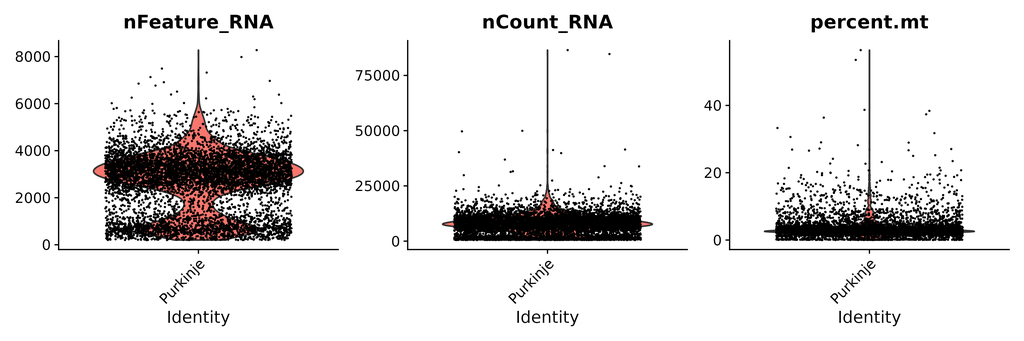

E16.5 Rep1 - Before QC

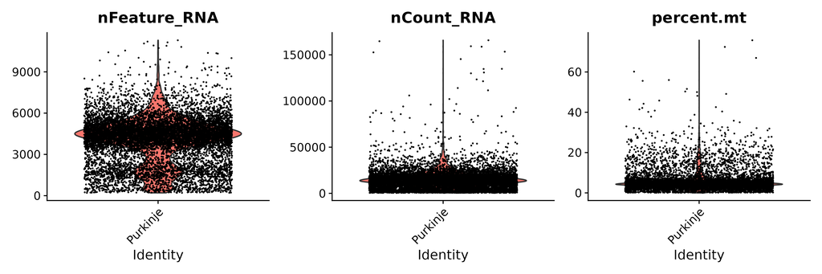

E16.5 Rep2 - Before QC

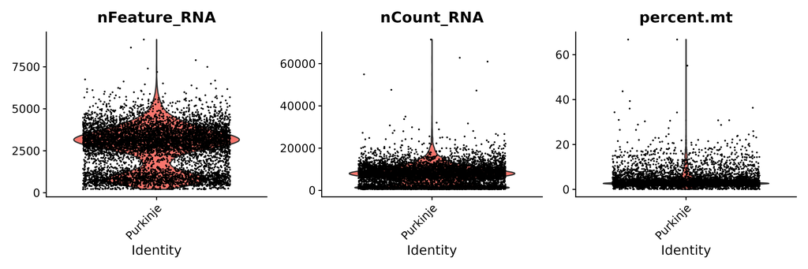

E18.5 - Before QC